# Google Data Analytics Capstone Project: Bellabeat

### Summary

In this case study, we imagine that we are a junior data analyst working for Bellabeat, a high-tech manufacturer of health focused products for women. In this scenario, Bellabeat is interested in analyzing and supplementing non-customer user data from other fitness wearables in order to inform decisions in marketing its products more effectively. **Note: This is a work in progress, and it will become more thorough/polished as time goes on**

### Business Task

Identify patterns in data of fitness wearable users that can contribute to more effective marketing strategies for Bellabeat.

### The Data

For this task, we have been asked to use fitbit user data provided by Kaggle. You can access the data [here](https://www.kaggle.com/datasets/arashnic/fitbit). We have been told that this dataset includespersonal fitness tracker data from thirty fitbit users who consented to the submission of personal tracker data, including minute-level output for physical activity, heart rate, and sleep monitoring which we intend to analyze to explore user habits. We have also been informed that this dataset may not be complete, and we may need to suplement it with data found elsewhere. To begin, let's import the data and do some primary exploratory analysis.

```python
#Import necessary packages
import pandas as pd
import numpy as np
import matplotlib.pyplot as plt
import os
import glob
#Double check the name of our current working directory
print(os.getcwd())
```

```
C:\Users\jeffu\bella_beat_casestudy
```

# Preliminary Data Exploration

```python
path = os.path.join(os.getcwd(),"Fitbit_Data")

csv_files = glob.glob(os.path.join(path, "*.csv"))
df_list = []
file_names = []
#Loop over csv files to get a quick glimpse at each of our tables
for f in csv_files:

    # read the csv file
    df = pd.read_csv(f)
    df_list.append(df)
    file_names.append(f.split("\\")[-1])
    # print the location and filename
    print('Location:', f)
    print('File Name:', f.split("\\")[-1])

    # print the content
    print('Content:')
    display(df)
    print()
```

```
Location: C:\Users\jeffu\bella_beat_casestudy\Fitbit_Data\dailyActivity_merged.csv
File Name: dailyActivity_merged.csv
Content:
```

|  | Id | ActivityDate | TotalSteps | TotalDistance | TrackerDistance | LoggedActivitiesDistance | VeryActiveDistance | ModeratelyActiveDistance | LightActiveDistance | SedentaryActiveDistance | VeryActiveMinutes | FairlyActiveMinutes | LightlyActiveMinutes | SedentaryMinutes | Calories |
| --- | --- | --- | --- | --- | --- | --- | --- | --- | --- | --- | --- | --- | --- | --- | --- |
| 0 | 1503960366 | 4/12/2016 | 13162 | 8.500000 | 8.500000 | 0.0 | 1.88 | 0.55 | 6.06 | 0.00 | 25 | 13 | 328 | 728 | 1985 |
| 1 | 1503960366 | 4/13/2016 | 10735 | 6.970000 | 6.970000 | 0.0 | 1.57 | 0.69 | 4.71 | 0.00 | 21 | 19 | 217 | 776 | 1797 |
| 2 | 1503960366 | 4/14/2016 | 10460 | 6.740000 | 6.740000 | 0.0 | 2.44 | 0.40 | 3.91 | 0.00 | 30 | 11 | 181 | 1218 | 1776 |
| 3 | 1503960366 | 4/15/2016 | 9762 | 6.280000 | 6.280000 | 0.0 | 2.14 | 1.26 | 2.83 | 0.00 | 29 | 34 | 209 | 726 | 1745 |
| 4 | 1503960366 | 4/16/2016 | 12669 | 8.160000 | 8.160000 | 0.0 | 2.71 | 0.41 | 5.04 | 0.00 | 36 | 10 | 221 | 773 | 1863 |
| ... | ... | ... | ... | ... | ... | ... | ... | ... | ... | ... | ... | ... | ... | ... | ... |
| 935 | 8877689391 | 5/8/2016 | 10686 | 8.110000 | 8.110000 | 0.0 | 1.08 | 0.20 | 6.80 | 0.00 | 17 | 4 | 245 | 1174 | 2847 |
| 936 | 8877689391 | 5/9/2016 | 20226 | 18.250000 | 18.250000 | 0.0 | 11.10 | 0.80 | 6.24 | 0.05 | 73 | 19 | 217 | 1131 | 3710 |
| 937 | 8877689391 | 5/10/2016 | 10733 | 8.150000 | 8.150000 | 0.0 | 1.35 | 0.46 | 6.28 | 0.00 | 18 | 11 | 224 | 1187 | 2832 |
| 938 | 8877689391 | 5/11/2016 | 21420 | 19.559999 | 19.559999 | 0.0 | 13.22 | 0.41 | 5.89 | 0.00 | 88 | 12 | 213 | 1127 | 3832 |
| 939 | 8877689391 | 5/12/2016 | 8064 | 6.120000 | 6.120000 | 0.0 | 1.82 | 0.04 | 4.25 | 0.00 | 23 | 1 | 137 | 770 | 1849 |

940 rows × 15 columns

```
Location: C:\Users\jeffu\bella_beat_casestudy\Fitbit_Data\dailyCalories_merged.csv
File Name: dailyCalories_merged.csv
Content:
```

|  | Id | ActivityDay | Calories |
| --- | --- | --- | --- |
| 0 | 1503960366 | 4/12/2016 | 1985 |
| 1 | 1503960366 | 4/13/2016 | 1797 |
| 2 | 1503960366 | 4/14/2016 | 1776 |
| 3 | 1503960366 | 4/15/2016 | 1745 |
| 4 | 1503960366 | 4/16/2016 | 1863 |
| ... | ... | ... | ... |
| 935 | 8877689391 | 5/8/2016 | 2847 |
| 936 | 8877689391 | 5/9/2016 | 3710 |
| 937 | 8877689391 | 5/10/2016 | 2832 |
| 938 | 8877689391 | 5/11/2016 | 3832 |
| 939 | 8877689391 | 5/12/2016 | 1849 |

940 rows × 3 columns

```
Location: C:\Users\jeffu\bella_beat_casestudy\Fitbit_Data\dailyIntensities_merged.csv
File Name: dailyIntensities_merged.csv
Content:
```

|  | Id | ActivityDay | SedentaryMinutes | LightlyActiveMinutes | FairlyActiveMinutes | VeryActiveMinutes | SedentaryActiveDistance | LightActiveDistance | ModeratelyActiveDistance | VeryActiveDistance |
| --- | --- | --- | --- | --- | --- | --- | --- | --- | --- | --- |
| 0 | 1503960366 | 4/12/2016 | 728 | 328 | 13 | 25 | 0.00 | 6.06 | 0.55 | 1.88 |
| 1 | 1503960366 | 4/13/2016 | 776 | 217 | 19 | 21 | 0.00 | 4.71 | 0.69 | 1.57 |
| 2 | 1503960366 | 4/14/2016 | 1218 | 181 | 11 | 30 | 0.00 | 3.91 | 0.40 | 2.44 |
| 3 | 1503960366 | 4/15/2016 | 726 | 209 | 34 | 29 | 0.00 | 2.83 | 1.26 | 2.14 |
| 4 | 1503960366 | 4/16/2016 | 773 | 221 | 10 | 36 | 0.00 | 5.04 | 0.41 | 2.71 |
| ... | ... | ... | ... | ... | ... | ... | ... | ... | ... | ... |
| 935 | 8877689391 | 5/8/2016 | 1174 | 245 | 4 | 17 | 0.00 | 6.80 | 0.20 | 1.08 |
| 936 | 8877689391 | 5/9/2016 | 1131 | 217 | 19 | 73 | 0.05 | 6.24 | 0.80 | 11.10 |
| 937 | 8877689391 | 5/10/2016 | 1187 | 224 | 11 | 18 | 0.00 | 6.28 | 0.46 | 1.35 |
| 938 | 8877689391 | 5/11/2016 | 1127 | 213 | 12 | 88 | 0.00 | 5.89 | 0.41 | 13.22 |
| 939 | 8877689391 | 5/12/2016 | 770 | 137 | 1 | 23 | 0.00 | 4.25 | 0.04 | 1.82 |

940 rows × 10 columns

```
Location: C:\Users\jeffu\bella_beat_casestudy\Fitbit_Data\dailySteps_merged.csv
File Name: dailySteps_merged.csv
Content:
```

|  | Id | ActivityDay | StepTotal |
| --- | --- | --- | --- |
| 0 | 1503960366 | 4/12/2016 | 13162 |
| 1 | 1503960366 | 4/13/2016 | 10735 |
| 2 | 1503960366 | 4/14/2016 | 10460 |
| 3 | 1503960366 | 4/15/2016 | 9762 |
| 4 | 1503960366 | 4/16/2016 | 12669 |
| ... | ... | ... | ... |
| 935 | 8877689391 | 5/8/2016 | 10686 |
| 936 | 8877689391 | 5/9/2016 | 20226 |
| 937 | 8877689391 | 5/10/2016 | 10733 |
| 938 | 8877689391 | 5/11/2016 | 21420 |
| 939 | 8877689391 | 5/12/2016 | 8064 |

940 rows × 3 columns

```
Location: C:\Users\jeffu\bella_beat_casestudy\Fitbit_Data\heartrate_seconds_merged.csv
File Name: heartrate_seconds_merged.csv
Content:
```

|  | Id | Time | Value |
| --- | --- | --- | --- |
| 0 | 2022484408 | 4/12/2016 7:21:00 AM | 97 |
| 1 | 2022484408 | 4/12/2016 7:21:05 AM | 102 |
| 2 | 2022484408 | 4/12/2016 7:21:10 AM | 105 |
| 3 | 2022484408 | 4/12/2016 7:21:20 AM | 103 |
| 4 | 2022484408 | 4/12/2016 7:21:25 AM | 101 |
| ... | ... | ... | ... |
| 2483653 | 8877689391 | 5/12/2016 2:43:53 PM | 57 |
| 2483654 | 8877689391 | 5/12/2016 2:43:58 PM | 56 |
| 2483655 | 8877689391 | 5/12/2016 2:44:03 PM | 55 |
| 2483656 | 8877689391 | 5/12/2016 2:44:18 PM | 55 |
| 2483657 | 8877689391 | 5/12/2016 2:44:28 PM | 56 |

2483658 rows × 3 columns

```
Location: C:\Users\jeffu\bella_beat_casestudy\Fitbit_Data\hourlyCalories_merged.csv
File Name: hourlyCalories_merged.csv
Content:
```

|  | Id | ActivityHour | Calories |
| --- | --- | --- | --- |
| 0 | 1503960366 | 4/12/2016 12:00:00 AM | 81 |
| 1 | 1503960366 | 4/12/2016 1:00:00 AM | 61 |
| 2 | 1503960366 | 4/12/2016 2:00:00 AM | 59 |
| 3 | 1503960366 | 4/12/2016 3:00:00 AM | 47 |
| 4 | 1503960366 | 4/12/2016 4:00:00 AM | 48 |
| ... | ... | ... | ... |
| 22094 | 8877689391 | 5/12/2016 10:00:00 AM | 126 |
| 22095 | 8877689391 | 5/12/2016 11:00:00 AM | 192 |
| 22096 | 8877689391 | 5/12/2016 12:00:00 PM | 321 |
| 22097 | 8877689391 | 5/12/2016 1:00:00 PM | 101 |
| 22098 | 8877689391 | 5/12/2016 2:00:00 PM | 113 |

22099 rows × 3 columns

```
Location: C:\Users\jeffu\bella_beat_casestudy\Fitbit_Data\hourlyIntensities_merged.csv
File Name: hourlyIntensities_merged.csv
Content:
```

|  | Id | ActivityHour | TotalIntensity | AverageIntensity |
| --- | --- | --- | --- | --- |
| 0 | 1503960366 | 4/12/2016 12:00:00 AM | 20 | 0.333333 |
| 1 | 1503960366 | 4/12/2016 1:00:00 AM | 8 | 0.133333 |
| 2 | 1503960366 | 4/12/2016 2:00:00 AM | 7 | 0.116667 |
| 3 | 1503960366 | 4/12/2016 3:00:00 AM | 0 | 0.000000 |
| 4 | 1503960366 | 4/12/2016 4:00:00 AM | 0 | 0.000000 |
| ... | ... | ... | ... | ... |
| 22094 | 8877689391 | 5/12/2016 10:00:00 AM | 12 | 0.200000 |
| 22095 | 8877689391 | 5/12/2016 11:00:00 AM | 29 | 0.483333 |
| 22096 | 8877689391 | 5/12/2016 12:00:00 PM | 93 | 1.550000 |
| 22097 | 8877689391 | 5/12/2016 1:00:00 PM | 6 | 0.100000 |
| 22098 | 8877689391 | 5/12/2016 2:00:00 PM | 9 | 0.150000 |

22099 rows × 4 columns

```
Location: C:\Users\jeffu\bella_beat_casestudy\Fitbit_Data\hourlySteps_merged.csv
File Name: hourlySteps_merged.csv
Content:
```

|  | Id | ActivityHour | StepTotal |
| --- | --- | --- | --- |
| 0 | 1503960366 | 4/12/2016 12:00:00 AM | 373 |
| 1 | 1503960366 | 4/12/2016 1:00:00 AM | 160 |
| 2 | 1503960366 | 4/12/2016 2:00:00 AM | 151 |
| 3 | 1503960366 | 4/12/2016 3:00:00 AM | 0 |
| 4 | 1503960366 | 4/12/2016 4:00:00 AM | 0 |
| ... | ... | ... | ... |
| 22094 | 8877689391 | 5/12/2016 10:00:00 AM | 514 |
| 22095 | 8877689391 | 5/12/2016 11:00:00 AM | 1407 |
| 22096 | 8877689391 | 5/12/2016 12:00:00 PM | 3135 |
| 22097 | 8877689391 | 5/12/2016 1:00:00 PM | 307 |
| 22098 | 8877689391 | 5/12/2016 2:00:00 PM | 457 |

22099 rows × 3 columns

```
Location: C:\Users\jeffu\bella_beat_casestudy\Fitbit_Data\minuteCaloriesNarrow_merged.csv
File Name: minuteCaloriesNarrow_merged.csv
Content:
```

|  | Id | ActivityMinute | Calories |
| --- | --- | --- | --- |
| 0 | 1503960366 | 4/12/2016 12:00:00 AM | 0.78650 |
| 1 | 1503960366 | 4/12/2016 12:01:00 AM | 0.78650 |
| 2 | 1503960366 | 4/12/2016 12:02:00 AM | 0.78650 |
| 3 | 1503960366 | 4/12/2016 12:03:00 AM | 0.78650 |
| 4 | 1503960366 | 4/12/2016 12:04:00 AM | 0.78650 |
| ... | ... | ... | ... |
| 1325575 | 8877689391 | 5/12/2016 1:55:00 PM | 1.33353 |
| 1325576 | 8877689391 | 5/12/2016 1:56:00 PM | 1.33353 |
| 1325577 | 8877689391 | 5/12/2016 1:57:00 PM | 1.33353 |
| 1325578 | 8877689391 | 5/12/2016 1:58:00 PM | 1.33353 |
| 1325579 | 8877689391 | 5/12/2016 1:59:00 PM | 1.33353 |

1325580 rows × 3 columns

```
Location: C:\Users\jeffu\bella_beat_casestudy\Fitbit_Data\minuteCaloriesWide_merged.csv
File Name: minuteCaloriesWide_merged.csv
Content:
```

|  | Id | ActivityHour | Calories00 | Calories01 | Calories02 | Calories03 | Calories04 | Calories05 | Calories06 | Calories07 | ... | Calories50 | Calories51 | Calories52 | Calories53 | Calories54 | Calories55 | Calories56 | Calories57 | Calories58 | Calories59 |
| --- | --- | --- | --- | --- | --- | --- | --- | --- | --- | --- | --- | --- | --- | --- | --- | --- | --- | --- | --- | --- | --- |
| 0 | 1503960366 | 4/13/2016 12:00:00 AM | 1.8876 | 2.2022 | 0.9438 | 0.9438 | 0.9438 | 2.0449 | 0.9438 | 2.2022 | ... | 0.9438 | 2.0449 | 2.0449 | 0.9438 | 2.3595 | 1.8876 | 0.9438 | 0.9438 | 0.9438 | 0.9438 |
| 1 | 1503960366 | 4/13/2016 1:00:00 AM | 0.7865 | 0.7865 | 0.7865 | 0.7865 | 0.9438 | 0.9438 | 0.9438 | 0.7865 | ... | 0.7865 | 0.7865 | 0.7865 | 0.7865 | 0.7865 | 0.7865 | 0.7865 | 0.7865 | 0.7865 | 0.7865 |
| 2 | 1503960366 | 4/13/2016 2:00:00 AM | 0.7865 | 0.7865 | 0.7865 | 0.7865 | 0.7865 | 0.7865 | 0.7865 | 0.7865 | ... | 0.7865 | 0.7865 | 0.7865 | 0.7865 | 0.7865 | 0.7865 | 0.7865 | 0.7865 | 0.7865 | 0.7865 |
| 3 | 1503960366 | 4/13/2016 3:00:00 AM | 0.7865 | 0.7865 | 0.7865 | 0.7865 | 0.7865 | 0.7865 | 0.7865 | 0.7865 | ... | 0.7865 | 0.7865 | 0.7865 | 0.7865 | 0.7865 | 0.7865 | 0.7865 | 0.7865 | 0.7865 | 0.7865 |
| 4 | 1503960366 | 4/13/2016 4:00:00 AM | 0.7865 | 0.7865 | 0.7865 | 0.7865 | 0.7865 | 0.7865 | 0.7865 | 0.7865 | ... | 0.7865 | 0.7865 | 0.7865 | 0.7865 | 0.7865 | 0.7865 | 0.7865 | 0.7865 | 0.7865 | 0.7865 |
| ... | ... | ... | ... | ... | ... | ... | ... | ... | ... | ... | ... | ... | ... | ... | ... | ... | ... | ... | ... | ... | ... |
| 21640 | 8877689391 | 5/13/2016 3:00:00 AM | 1.2170 | 1.2170 | 1.2170 | 1.2170 | 1.2170 | 1.2170 | 1.2170 | 1.2170 | ... | 1.2170 | 1.2170 | 1.2170 | 1.2170 | 1.2170 | 1.2170 | 1.2170 | 1.2170 | 1.2170 | 1.2170 |
| 21641 | 8877689391 | 5/13/2016 4:00:00 AM | 1.2170 | 1.2170 | 1.2170 | 1.2170 | 1.2170 | 1.2170 | 1.2170 | 1.2170 | ... | 1.2170 | 1.2170 | 1.2170 | 1.2170 | 1.2170 | 1.2170 | 1.2170 | 1.2170 | 1.2170 | 1.2170 |
| 21642 | 8877689391 | 5/13/2016 5:00:00 AM | 1.2170 | 1.2170 | 1.2170 | 1.2170 | 1.2170 | 1.2170 | 1.2170 | 1.2170 | ... | 1.2170 | 1.2170 | 1.2170 | 1.2170 | 1.2170 | 1.2170 | 1.2170 | 1.2170 | 1.2170 | 1.2170 |
| 21643 | 8877689391 | 5/13/2016 6:00:00 AM | 1.2170 | 1.2170 | 1.2170 | 1.2170 | 1.2170 | 1.2170 | 1.2170 | 1.2170 | ... | 4.6246 | 4.6246 | 4.8680 | 4.3812 | 4.3812 | 1.5821 | 1.5821 | 3.8944 | 4.6246 | 3.8944 |
| 21644 | 8877689391 | 5/13/2016 7:00:00 AM | 4.6246 | 4.1378 | 4.3812 | 1.8255 | 3.1642 | 1.5821 | 1.5821 | 1.5821 | ... | 1.5821 | 1.3387 | 1.5821 | 1.5821 | 1.3387 | 1.3387 | 1.5821 | 1.3387 | 1.3387 | 1.3387 |

21645 rows × 62 columns

```
Location: C:\Users\jeffu\bella_beat_casestudy\Fitbit_Data\minuteIntensitiesNarrow_merged.csv
File Name: minuteIntensitiesNarrow_merged.csv
Content:
```

|  | Id | ActivityMinute | Intensity |
| --- | --- | --- | --- |
| 0 | 1503960366 | 4/12/2016 12:00:00 AM | 0 |
| 1 | 1503960366 | 4/12/2016 12:01:00 AM | 0 |
| 2 | 1503960366 | 4/12/2016 12:02:00 AM | 0 |
| 3 | 1503960366 | 4/12/2016 12:03:00 AM | 0 |
| 4 | 1503960366 | 4/12/2016 12:04:00 AM | 0 |
| ... | ... | ... | ... |
| 1325575 | 8877689391 | 5/12/2016 1:55:00 PM | 0 |
| 1325576 | 8877689391 | 5/12/2016 1:56:00 PM | 0 |
| 1325577 | 8877689391 | 5/12/2016 1:57:00 PM | 0 |
| 1325578 | 8877689391 | 5/12/2016 1:58:00 PM | 0 |
| 1325579 | 8877689391 | 5/12/2016 1:59:00 PM | 0 |

1325580 rows × 3 columns

```
Location: C:\Users\jeffu\bella_beat_casestudy\Fitbit_Data\minuteIntensitiesWide_merged.csv
File Name: minuteIntensitiesWide_merged.csv
Content:
```

|  | Id | ActivityHour | Intensity00 | Intensity01 | Intensity02 | Intensity03 | Intensity04 | Intensity05 | Intensity06 | Intensity07 | ... | Intensity50 | Intensity51 | Intensity52 | Intensity53 | Intensity54 | Intensity55 | Intensity56 | Intensity57 | Intensity58 | Intensity59 |
| --- | --- | --- | --- | --- | --- | --- | --- | --- | --- | --- | --- | --- | --- | --- | --- | --- | --- | --- | --- | --- | --- |
| 0 | 1503960366 | 4/13/2016 12:00:00 AM | 1 | 1 | 0 | 0 | 0 | 1 | 0 | 1 | ... | 0 | 1 | 1 | 0 | 1 | 1 | 0 | 0 | 0 | 0 |
| 1 | 1503960366 | 4/13/2016 1:00:00 AM | 0 | 0 | 0 | 0 | 0 | 0 | 0 | 0 | ... | 0 | 0 | 0 | 0 | 0 | 0 | 0 | 0 | 0 | 0 |
| 2 | 1503960366 | 4/13/2016 2:00:00 AM | 0 | 0 | 0 | 0 | 0 | 0 | 0 | 0 | ... | 0 | 0 | 0 | 0 | 0 | 0 | 0 | 0 | 0 | 0 |
| 3 | 1503960366 | 4/13/2016 3:00:00 AM | 0 | 0 | 0 | 0 | 0 | 0 | 0 | 0 | ... | 0 | 0 | 0 | 0 | 0 | 0 | 0 | 0 | 0 | 0 |
| 4 | 1503960366 | 4/13/2016 4:00:00 AM | 0 | 0 | 0 | 0 | 0 | 0 | 0 | 0 | ... | 0 | 0 | 0 | 0 | 0 | 0 | 0 | 0 | 0 | 0 |
| ... | ... | ... | ... | ... | ... | ... | ... | ... | ... | ... | ... | ... | ... | ... | ... | ... | ... | ... | ... | ... | ... |
| 21640 | 8877689391 | 5/13/2016 3:00:00 AM | 0 | 0 | 0 | 0 | 0 | 0 | 0 | 0 | ... | 0 | 0 | 0 | 0 | 0 | 0 | 0 | 0 | 0 | 0 |
| 21641 | 8877689391 | 5/13/2016 4:00:00 AM | 0 | 0 | 0 | 0 | 0 | 0 | 0 | 0 | ... | 0 | 0 | 0 | 0 | 0 | 0 | 0 | 0 | 0 | 0 |
| 21642 | 8877689391 | 5/13/2016 5:00:00 AM | 0 | 0 | 0 | 0 | 0 | 0 | 0 | 0 | ... | 0 | 0 | 0 | 0 | 0 | 0 | 0 | 0 | 0 | 0 |
| 21643 | 8877689391 | 5/13/2016 6:00:00 AM | 0 | 0 | 0 | 0 | 0 | 0 | 0 | 0 | ... | 1 | 1 | 1 | 1 | 1 | 0 | 0 | 1 | 1 | 1 |
| 21644 | 8877689391 | 5/13/2016 7:00:00 AM | 1 | 1 | 1 | 0 | 1 | 0 | 0 | 0 | ... | 0 | 0 | 0 | 0 | 0 | 0 | 0 | 0 | 0 | 0 |

21645 rows × 62 columns

```
Location: C:\Users\jeffu\bella_beat_casestudy\Fitbit_Data\minuteMETsNarrow_merged.csv
File Name: minuteMETsNarrow_merged.csv
Content:
```

|  | Id | ActivityMinute | METs |
| --- | --- | --- | --- |
| 0 | 1503960366 | 4/12/2016 12:00:00 AM | 10 |
| 1 | 1503960366 | 4/12/2016 12:01:00 AM | 10 |
| 2 | 1503960366 | 4/12/2016 12:02:00 AM | 10 |
| 3 | 1503960366 | 4/12/2016 12:03:00 AM | 10 |
| 4 | 1503960366 | 4/12/2016 12:04:00 AM | 10 |
| ... | ... | ... | ... |
| 1325575 | 8877689391 | 5/12/2016 1:55:00 PM | 11 |
| 1325576 | 8877689391 | 5/12/2016 1:56:00 PM | 11 |
| 1325577 | 8877689391 | 5/12/2016 1:57:00 PM | 11 |
| 1325578 | 8877689391 | 5/12/2016 1:58:00 PM | 11 |
| 1325579 | 8877689391 | 5/12/2016 1:59:00 PM | 11 |

1325580 rows × 3 columns

```
Location: C:\Users\jeffu\bella_beat_casestudy\Fitbit_Data\minuteSleep_merged.csv
File Name: minuteSleep_merged.csv
Content:
```

|  | Id | date | value | logId |
| --- | --- | --- | --- | --- |
| 0 | 1503960366 | 4/12/2016 2:47:30 AM | 3 | 11380564589 |
| 1 | 1503960366 | 4/12/2016 2:48:30 AM | 2 | 11380564589 |
| 2 | 1503960366 | 4/12/2016 2:49:30 AM | 1 | 11380564589 |
| 3 | 1503960366 | 4/12/2016 2:50:30 AM | 1 | 11380564589 |
| 4 | 1503960366 | 4/12/2016 2:51:30 AM | 1 | 11380564589 |
| ... | ... | ... | ... | ... |
| 188516 | 8792009665 | 5/4/2016 9:59:00 AM | 1 | 11552534115 |
| 188517 | 8792009665 | 5/4/2016 10:00:00 AM | 1 | 11552534115 |
| 188518 | 8792009665 | 5/4/2016 10:01:00 AM | 1 | 11552534115 |
| 188519 | 8792009665 | 5/4/2016 10:02:00 AM | 1 | 11552534115 |
| 188520 | 8792009665 | 5/4/2016 10:03:00 AM | 1 | 11552534115 |

188521 rows × 4 columns

```
Location: C:\Users\jeffu\bella_beat_casestudy\Fitbit_Data\minuteStepsNarrow_merged.csv
File Name: minuteStepsNarrow_merged.csv
Content:
```

|  | Id | ActivityMinute | Steps |
| --- | --- | --- | --- |
| 0 | 1503960366 | 4/12/2016 12:00:00 AM | 0 |
| 1 | 1503960366 | 4/12/2016 12:01:00 AM | 0 |
| 2 | 1503960366 | 4/12/2016 12:02:00 AM | 0 |
| 3 | 1503960366 | 4/12/2016 12:03:00 AM | 0 |
| 4 | 1503960366 | 4/12/2016 12:04:00 AM | 0 |
| ... | ... | ... | ... |
| 1325575 | 8877689391 | 5/12/2016 1:55:00 PM | 0 |
| 1325576 | 8877689391 | 5/12/2016 1:56:00 PM | 0 |
| 1325577 | 8877689391 | 5/12/2016 1:57:00 PM | 0 |
| 1325578 | 8877689391 | 5/12/2016 1:58:00 PM | 0 |
| 1325579 | 8877689391 | 5/12/2016 1:59:00 PM | 0 |

1325580 rows × 3 columns

```
Location: C:\Users\jeffu\bella_beat_casestudy\Fitbit_Data\minuteStepsWide_merged.csv
File Name: minuteStepsWide_merged.csv
Content:
```

|  | Id | ActivityHour | Steps00 | Steps01 | Steps02 | Steps03 | Steps04 | Steps05 | Steps06 | Steps07 | ... | Steps50 | Steps51 | Steps52 | Steps53 | Steps54 | Steps55 | Steps56 | Steps57 | Steps58 | Steps59 |
| --- | --- | --- | --- | --- | --- | --- | --- | --- | --- | --- | --- | --- | --- | --- | --- | --- | --- | --- | --- | --- | --- |
| 0 | 1503960366 | 4/13/2016 12:00:00 AM | 4 | 16 | 0 | 0 | 0 | 9 | 0 | 17 | ... | 0 | 9 | 8 | 0 | 20 | 1 | 0 | 0 | 0 | 0 |
| 1 | 1503960366 | 4/13/2016 1:00:00 AM | 0 | 0 | 0 | 0 | 0 | 0 | 0 | 0 | ... | 0 | 0 | 0 | 0 | 0 | 0 | 0 | 0 | 0 | 0 |
| 2 | 1503960366 | 4/13/2016 2:00:00 AM | 0 | 0 | 0 | 0 | 0 | 0 | 0 | 0 | ... | 0 | 0 | 0 | 0 | 0 | 0 | 0 | 0 | 0 | 0 |
| 3 | 1503960366 | 4/13/2016 3:00:00 AM | 0 | 0 | 0 | 0 | 0 | 0 | 0 | 0 | ... | 0 | 0 | 0 | 0 | 0 | 0 | 0 | 0 | 0 | 0 |
| 4 | 1503960366 | 4/13/2016 4:00:00 AM | 0 | 0 | 0 | 0 | 0 | 0 | 0 | 0 | ... | 0 | 0 | 0 | 0 | 0 | 0 | 0 | 0 | 0 | 0 |
| ... | ... | ... | ... | ... | ... | ... | ... | ... | ... | ... | ... | ... | ... | ... | ... | ... | ... | ... | ... | ... | ... |
| 21640 | 8877689391 | 5/13/2016 3:00:00 AM | 0 | 0 | 0 | 0 | 0 | 0 | 0 | 0 | ... | 0 | 0 | 0 | 0 | 0 | 0 | 0 | 0 | 0 | 0 |
| 21641 | 8877689391 | 5/13/2016 4:00:00 AM | 0 | 0 | 0 | 0 | 0 | 0 | 0 | 0 | ... | 0 | 0 | 0 | 0 | 0 | 0 | 0 | 0 | 0 | 0 |
| 21642 | 8877689391 | 5/13/2016 5:00:00 AM | 0 | 0 | 0 | 0 | 0 | 0 | 0 | 0 | ... | 0 | 0 | 0 | 0 | 0 | 0 | 0 | 0 | 0 | 0 |
| 21643 | 8877689391 | 5/13/2016 6:00:00 AM | 0 | 0 | 0 | 0 | 0 | 0 | 0 | 0 | ... | 21 | 22 | 33 | 17 | 24 | 0 | 0 | 20 | 38 | 16 |
| 21644 | 8877689391 | 5/13/2016 7:00:00 AM | 35 | 21 | 44 | 0 | 6 | 0 | 0 | 0 | ... | 0 | 0 | 0 | 0 | 0 | 0 | 0 | 0 | 0 | 0 |

21645 rows × 62 columns

```
Location: C:\Users\jeffu\bella_beat_casestudy\Fitbit_Data\sleepDay_merged.csv
File Name: sleepDay_merged.csv
Content:
```

|  | Id | SleepDay | TotalSleepRecords | TotalMinutesAsleep | TotalTimeInBed |
| --- | --- | --- | --- | --- | --- |
| 0 | 1503960366 | 4/12/2016 12:00:00 AM | 1 | 327 | 346 |
| 1 | 1503960366 | 4/13/2016 12:00:00 AM | 2 | 384 | 407 |
| 2 | 1503960366 | 4/15/2016 12:00:00 AM | 1 | 412 | 442 |
| 3 | 1503960366 | 4/16/2016 12:00:00 AM | 2 | 340 | 367 |
| 4 | 1503960366 | 4/17/2016 12:00:00 AM | 1 | 700 | 712 |
| ... | ... | ... | ... | ... | ... |
| 408 | 8792009665 | 4/30/2016 12:00:00 AM | 1 | 343 | 360 |
| 409 | 8792009665 | 5/1/2016 12:00:00 AM | 1 | 503 | 527 |
| 410 | 8792009665 | 5/2/2016 12:00:00 AM | 1 | 415 | 423 |
| 411 | 8792009665 | 5/3/2016 12:00:00 AM | 1 | 516 | 545 |
| 412 | 8792009665 | 5/4/2016 12:00:00 AM | 1 | 439 | 463 |

413 rows × 5 columns

```
Location: C:\Users\jeffu\bella_beat_casestudy\Fitbit_Data\weightLogInfo_merged.csv
File Name: weightLogInfo_merged.csv
Content:
```

|  | Id | Date | WeightKg | WeightPounds | Fat | BMI | IsManualReport | LogId |
| --- | --- | --- | --- | --- | --- | --- | --- | --- |
| 0 | 1503960366 | 5/2/2016 11:59:59 PM | 52.599998 | 115.963147 | 22.0 | 22.650000 | True | 1462233599000 |
| 1 | 1503960366 | 5/3/2016 11:59:59 PM | 52.599998 | 115.963147 | NaN | 22.650000 | True | 1462319999000 |
| 2 | 1927972279 | 4/13/2016 1:08:52 AM | 133.500000 | 294.317120 | NaN | 47.540001 | False | 1460509732000 |
| 3 | 2873212765 | 4/21/2016 11:59:59 PM | 56.700001 | 125.002104 | NaN | 21.450001 | True | 1461283199000 |
| 4 | 2873212765 | 5/12/2016 11:59:59 PM | 57.299999 | 126.324875 | NaN | 21.690001 | True | 1463097599000 |
| ... | ... | ... | ... | ... | ... | ... | ... | ... |
| 62 | 8877689391 | 5/6/2016 6:43:35 AM | 85.000000 | 187.392923 | NaN | 25.440001 | False | 1462517015000 |
| 63 | 8877689391 | 5/8/2016 7:35:53 AM | 85.400002 | 188.274775 | NaN | 25.559999 | False | 1462692953000 |
| 64 | 8877689391 | 5/9/2016 6:39:44 AM | 85.500000 | 188.495234 | NaN | 25.610001 | False | 1462775984000 |
| 65 | 8877689391 | 5/11/2016 6:51:47 AM | 85.400002 | 188.274775 | NaN | 25.559999 | False | 1462949507000 |
| 66 | 8877689391 | 5/12/2016 6:42:53 AM | 84.000000 | 185.188300 | NaN | 25.139999 | False | 1463035373000 |

67 rows × 8 columns

Upon a quick glance through these tables, there are a few key things that we can see to help us narrow down our focus.

1. Data is organized in either Daily, Hourly, or Minute format
2. For Daily data, we notice that the csv's for calories, intensities, and steps are already included in the dailyActivity csv.
3. There is no such table that joins together multiple metrics for hourly or minute.
4. All tables include an 'Id' column that should be able to be used as a primary key.

With this in mind, let's try a few things. First, let's explore whether 'Id' can truly be used as a primary key to join these tables. We'll double check that 'Id' is included in the column names of each table.

```python
#Initialize counter at 0 to track number of tables that don't include an 'Id' column
count = 0
#Loop through each dataframe and increment counter if 'Id' is not a column name
for df in df_list:
    if 'Id'  not in df.columns:
        count +=1

print(count)
```

```
0
```

Great! This confirms that the 'Id' column is included in each of the tables. Let's now check to make sure that each of our 30 subjects is included in every table. To do this, we'll take advantage of NumPy's built in "unique" function.

```python
for name, df in zip(file_names, df_list):
    unique_ids = len(list(np.unique(df.Id)))
    print(f'File: {name}, No. Unique Ids: {unique_ids}')
```

```
File: dailyActivity_merged.csv, No. Unique Ids: 33
File: dailyCalories_merged.csv, No. Unique Ids: 33
File: dailyIntensities_merged.csv, No. Unique Ids: 33
File: dailySteps_merged.csv, No. Unique Ids: 33
File: heartrate_seconds_merged.csv, No. Unique Ids: 14
File: hourlyCalories_merged.csv, No. Unique Ids: 33
File: hourlyIntensities_merged.csv, No. Unique Ids: 33
File: hourlySteps_merged.csv, No. Unique Ids: 33
File: minuteCaloriesNarrow_merged.csv, No. Unique Ids: 33
File: minuteCaloriesWide_merged.csv, No. Unique Ids: 33
File: minuteIntensitiesNarrow_merged.csv, No. Unique Ids: 33
File: minuteIntensitiesWide_merged.csv, No. Unique Ids: 33
File: minuteMETsNarrow_merged.csv, No. Unique Ids: 33
File: minuteSleep_merged.csv, No. Unique Ids: 24
File: minuteStepsNarrow_merged.csv, No. Unique Ids: 33
File: minuteStepsWide_merged.csv, No. Unique Ids: 33
File: sleepDay_merged.csv, No. Unique Ids: 24
File: weightLogInfo_merged.csv, No. Unique Ids: 8
```

OK, we've run into our first interesting speed bump. We were told that there were only 30 users represented in this data, but our analysis actually indicates that there are 33. We'll need to validate whether there truly our 33 users, or if there is an error in the way of ID tracking. Next, note that for certain tables, not every user is represented. It seems, however that the missing dat ais only seen in second, minute, sleep, and weight info data. That is helpful knowledge at this point.

From our early exploration, we plan on utilizing 4 main tables for analysis.

1. daily activity
2. hourly activity
   - We will have to create this table by joining together our other hourly dataframes
3. daily sleep
4. weight log info
   - We know that only 8 participants are included here, but it may still give us useful information.

Because we are only looking to use our analysis for high level recommendations for marketing strategies, we will not look into the minute and second level data for now. Let's start by first making our hourly activity dataframe, then we will save the other tables we need, and delete the rest.

# Data Cleaning

```python
#First, let's grab the dataframes that include hourly data.
#Remember that when slicing lists in Python, we start indexing at 0, include our first entry, and don't include the end entry
#Since our desired dataframes are the 6th-8th, that equates to 5:8
hourly_dfs = df_list[5:8]


#Now let's join our dataframes together. We'll merge them on both Id and ActivityHour.
#This assumes userdata will occur on the same day

for i, df in enumerate(hourly_dfs):
    print(df.shape)
    if i== 0:
        hourly_activity = df
    else:
        hourly_activity = hourly_activity.merge(df, how='outer', on = ['Id','ActivityHour'])
#We print the df shape here. Note that each has the same number of rows
```

```
(22099, 3)
(22099, 4)
(22099, 3)
```

```python
hourly_activity.shape
```

```
(22099, 6)
```

```python
hourly_activity.isnull().sum()
```

```
Id                  0
ActivityHour        0
Calories            0
TotalIntensity      0
AverageIntensity    0
StepTotal           0
dtype: int64
```

```python
daily_activity = df_list[0]
daily_sleep = df_list[-2]
weight_data = df_list[-1]

del df_list
```

```python
daily_activity.head()
```

|  | Id | ActivityDate | TotalSteps | TotalDistance | TrackerDistance | LoggedActivitiesDistance | VeryActiveDistance | ModeratelyActiveDistance | LightActiveDistance | SedentaryActiveDistance | VeryActiveMinutes | FairlyActiveMinutes | LightlyActiveMinutes | SedentaryMinutes | Calories |
| --- | --- | --- | --- | --- | --- | --- | --- | --- | --- | --- | --- | --- | --- | --- | --- |
| 0 | 1503960366 | 4/12/2016 | 13162 | 8.50 | 8.50 | 0.0 | 1.88 | 0.55 | 6.06 | 0.0 | 25 | 13 | 328 | 728 | 1985 |
| 1 | 1503960366 | 4/13/2016 | 10735 | 6.97 | 6.97 | 0.0 | 1.57 | 0.69 | 4.71 | 0.0 | 21 | 19 | 217 | 776 | 1797 |
| 2 | 1503960366 | 4/14/2016 | 10460 | 6.74 | 6.74 | 0.0 | 2.44 | 0.40 | 3.91 | 0.0 | 30 | 11 | 181 | 1218 | 1776 |
| 3 | 1503960366 | 4/15/2016 | 9762 | 6.28 | 6.28 | 0.0 | 2.14 | 1.26 | 2.83 | 0.0 | 29 | 34 | 209 | 726 | 1745 |
| 4 | 1503960366 | 4/16/2016 | 12669 | 8.16 | 8.16 | 0.0 | 2.71 | 0.41 | 5.04 | 0.0 | 36 | 10 | 221 | 773 | 1863 |

```python
daily_sleep.head()
```

|  | Id | SleepDay | TotalSleepRecords | TotalMinutesAsleep | TotalTimeInBed |
| --- | --- | --- | --- | --- | --- |
| 0 | 1503960366 | 4/12/2016 12:00:00 AM | 1 | 327 | 346 |
| 1 | 1503960366 | 4/13/2016 12:00:00 AM | 2 | 384 | 407 |
| 2 | 1503960366 | 4/15/2016 12:00:00 AM | 1 | 412 | 442 |
| 3 | 1503960366 | 4/16/2016 12:00:00 AM | 2 | 340 | 367 |
| 4 | 1503960366 | 4/17/2016 12:00:00 AM | 1 | 700 | 712 |

```python
#Save to csvs for use with tableau dashboard later
hourly_activity.to_csv('HourlyData.csv')
daily_activity.to_csv('DailyData.csv')
daily_sleep.to_csv('DailySleep.csv')
weight_data.to_csv('WeightData.csv')
```

# Analysis Leading to Further Cleaning

Now that we have our datasets cleaned and prepared, it's time for analysis! Let's start by exploring and visualizing the daily activity

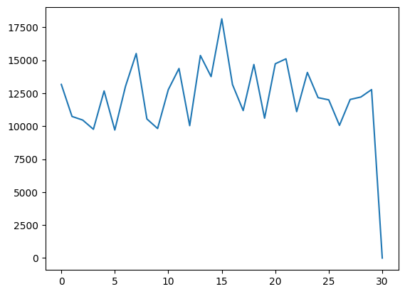

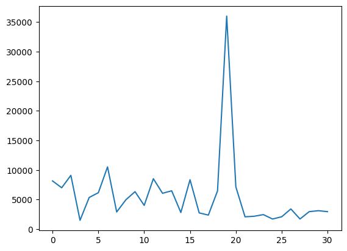

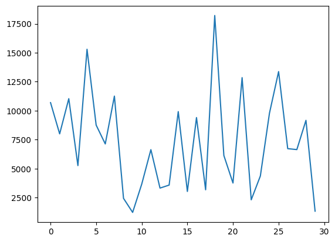

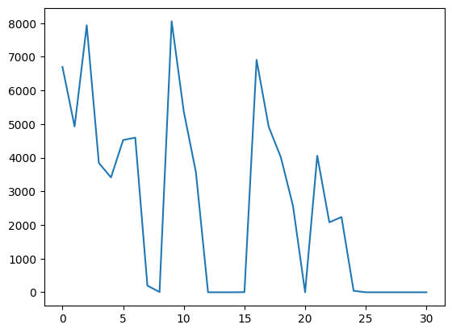

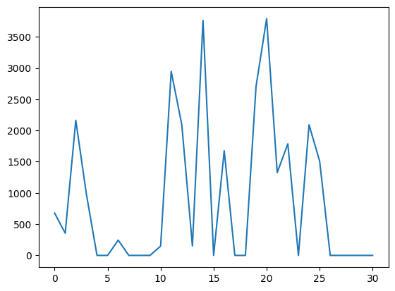

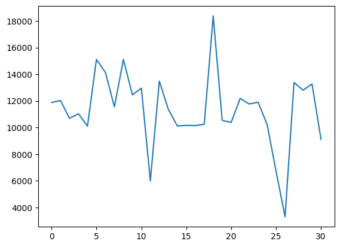

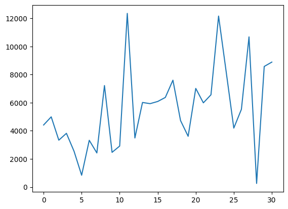

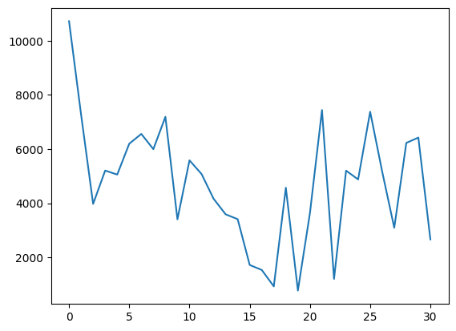

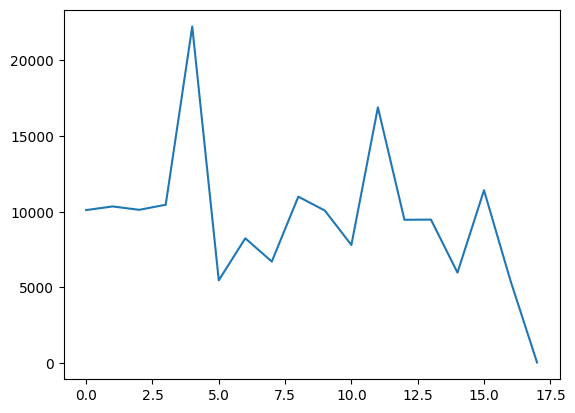

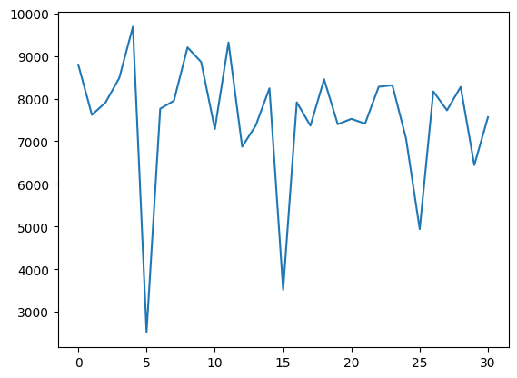

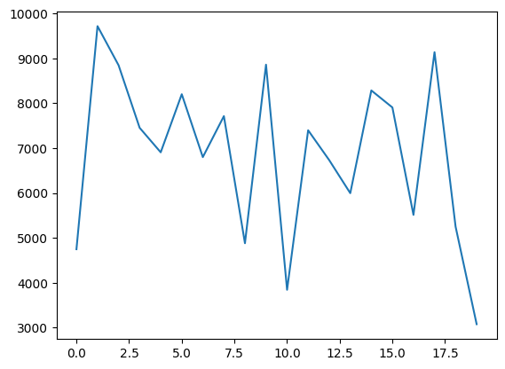

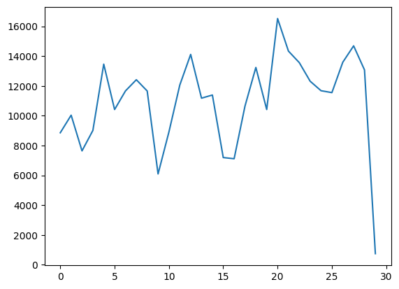

[21 more figures not shown]

```python
grouped = daily_activity.groupby('Id')
for Id, group in grouped:
    plt.plot(np.arange(group.shape[0]),group.TotalSteps)
    plt.show()
```

**Discovery** From plotting daily steps by user, there is definitely a wide range in how much users actually use their fitbit. In particular, it is interesting that a large number of entries include 0 daily steps. Let's look at all entries where daily steps are equal to zero to see if any other metrics are being tracked for that day, or if the user likely forgot to wear their fitbit on those days.

```python
zero_daily_steps = daily_activity[daily_activity.TotalSteps==0]
```

```python
zero_daily_steps.drop(['Id'],axis=1).describe()
```

|  | TotalSteps | TotalDistance | TrackerDistance | LoggedActivitiesDistance | VeryActiveDistance | ModeratelyActiveDistance | LightActiveDistance | SedentaryActiveDistance | VeryActiveMinutes | FairlyActiveMinutes | LightlyActiveMinutes | SedentaryMinutes | Calories |
| --- | --- | --- | --- | --- | --- | --- | --- | --- | --- | --- | --- | --- | --- |
| count | 77.0 | 77.0 | 77.0 | 77.0 | 77.0 | 77.0 | 77.0 | 77.0 | 77.000000 | 77.0 | 77.0 | 77.000000 | 77.000000 |
| mean | 0.0 | 0.0 | 0.0 | 0.0 | 0.0 | 0.0 | 0.0 | 0.0 | 0.428571 | 0.0 | 0.0 | 1388.610390 | 1657.077922 |
| std | 0.0 | 0.0 | 0.0 | 0.0 | 0.0 | 0.0 | 0.0 | 0.0 | 3.760699 | 0.0 | 0.0 | 236.692181 | 557.082290 |
| min | 0.0 | 0.0 | 0.0 | 0.0 | 0.0 | 0.0 | 0.0 | 0.0 | 0.000000 | 0.0 | 0.0 | 48.000000 | 0.000000 |
| 25% | 0.0 | 0.0 | 0.0 | 0.0 | 0.0 | 0.0 | 0.0 | 0.0 | 0.000000 | 0.0 | 0.0 | 1440.000000 | 1496.000000 |
| 50% | 0.0 | 0.0 | 0.0 | 0.0 | 0.0 | 0.0 | 0.0 | 0.0 | 0.000000 | 0.0 | 0.0 | 1440.000000 | 1841.000000 |
| 75% | 0.0 | 0.0 | 0.0 | 0.0 | 0.0 | 0.0 | 0.0 | 0.0 | 0.000000 | 0.0 | 0.0 | 1440.000000 | 1980.000000 |
| max | 0.0 | 0.0 | 0.0 | 0.0 | 0.0 | 0.0 | 0.0 | 0.0 | 33.000000 | 0.0 | 0.0 | 1440.000000 | 2664.000000 |

From the description of the days for which users took 0 total steps, it certainly appears that users were likely not wearing their fitbit. Let's keep track of the percentage of entries to report later, but then we'll drop these from our daily data.

```python
non_use_prct = zero_daily_steps.shape[0]/daily_activity.shape[0]*100
print(f'{non_use_prct:.2f}% of user entries had 0 daily steps recorded')
```

```
8.19% of user entries had 0 daily steps recorded
```

```python
for i,(Id, group) in enumerate(grouped):
    zero_daily_steps = group[group.TotalSteps==0]
    non_use_prct = zero_daily_steps.shape[0]/daily_activity.shape[0]*100
    print(f'User {i+1}, non-use percentage:{non_use_prct:.2f}%')
```

```
User 1, non-use percentage:0.11%
User 2, non-use percentage:0.00%
User 3, non-use percentage:0.00%
User 4, non-use percentage:1.06%
User 5, non-use percentage:1.49%
User 6, non-use percentage:0.00%
User 7, non-use percentage:0.00%
User 8, non-use percentage:0.00%
User 9, non-use percentage:0.00%
User 10, non-use percentage:0.00%
User 11, non-use percentage:0.00%
User 12, non-use percentage:0.00%
User 13, non-use percentage:1.49%
User 14, non-use percentage:0.11%
User 15, non-use percentage:0.00%
User 16, non-use percentage:0.00%
User 17, non-use percentage:0.00%
User 18, non-use percentage:0.00%
User 19, non-use percentage:0.11%
User 20, non-use percentage:0.00%
User 21, non-use percentage:0.21%
User 22, non-use percentage:0.53%
User 23, non-use percentage:0.53%
User 24, non-use percentage:0.96%
User 25, non-use percentage:0.00%
User 26, non-use percentage:0.21%
User 27, non-use percentage:0.11%
User 28, non-use percentage:0.00%
User 29, non-use percentage:0.11%
User 30, non-use percentage:0.00%
User 31, non-use percentage:0.11%
User 32, non-use percentage:1.06%
User 33, non-use percentage:0.00%
```

```python
daily_cleaned = daily_activity[daily_activity.TotalSteps!=0]
```

```python
daily_cleaned[daily_cleaned['TotalSteps']==0].shape
```

```
(0, 15)
```

# Analysis - take two

To market our product, we really want to use what data we have to try to come up with an idea of what type of people use fitness trackers, and in the process, since this data is from non-bellabeat users, we want to see if there are any gaps which bellabeat may be able to fill.

First, let's look at daily steps, calories burned, and sedentary minutes on average across all users, and by user.

```python
daily_cleaned.head()
```

|  | Id | ActivityDate | TotalSteps | TotalDistance | TrackerDistance | LoggedActivitiesDistance | VeryActiveDistance | ModeratelyActiveDistance | LightActiveDistance | SedentaryActiveDistance | VeryActiveMinutes | FairlyActiveMinutes | LightlyActiveMinutes | SedentaryMinutes | Calories |
| --- | --- | --- | --- | --- | --- | --- | --- | --- | --- | --- | --- | --- | --- | --- | --- |
| 0 | 1503960366 | 4/12/2016 | 13162 | 8.50 | 8.50 | 0.0 | 1.88 | 0.55 | 6.06 | 0.0 | 25 | 13 | 328 | 728 | 1985 |
| 1 | 1503960366 | 4/13/2016 | 10735 | 6.97 | 6.97 | 0.0 | 1.57 | 0.69 | 4.71 | 0.0 | 21 | 19 | 217 | 776 | 1797 |
| 2 | 1503960366 | 4/14/2016 | 10460 | 6.74 | 6.74 | 0.0 | 2.44 | 0.40 | 3.91 | 0.0 | 30 | 11 | 181 | 1218 | 1776 |
| 3 | 1503960366 | 4/15/2016 | 9762 | 6.28 | 6.28 | 0.0 | 2.14 | 1.26 | 2.83 | 0.0 | 29 | 34 | 209 | 726 | 1745 |
| 4 | 1503960366 | 4/16/2016 | 12669 | 8.16 | 8.16 | 0.0 | 2.71 | 0.41 | 5.04 | 0.0 | 36 | 10 | 221 | 773 | 1863 |

```python
avg_total_steps = np.mean(daily_cleaned.TotalSteps)
avg_calories = np.mean(daily_cleaned.Calories)
avg_sedentary = np.mean(daily_cleaned.SedentaryMinutes)
sedentary_hours = avg_sedentary//60
sedentary_minutes = avg_sedentary%60
print(f'Average Steps: {avg_total_steps: .2f} \nAverage Calories Burned: {avg_calories: .2f} \nAverage Sedentary Time: {sedentary_hours} hours and {sedentary_minutes} minutes')
```

```
Average Steps:  8319.39
Average Calories Burned:  2361.30
Average Sedentary Time: 15.0 hours and 55.753186558516745 minutes
```

```python
avg_sleep = np.mean(daily_sleep.TotalMinutesAsleep)
sleep_hours = avg_sleep//60
sleep_minutes = avg_sleep%60

print(f'Average sleep time: {sleep_hours} hours and {sleep_minutes} minutes')
```

```
Average sleep time: 6.0 hours and 59.46731234866826 minutes
```

**Discovery** Although we don't have sleep data for all of our 33 subjects, from what data we have, our potential clients sleep an average of 7 hours per night, which is great, but not quite up to the desired 8+ hours a night.

When you include sleep time in sedentary time, that leaves us with an average of around 9 hours of sedentary time daily. Our potential clients are likely working people who work sedentary jobs and may have a commute.

For people with relatively high sedentary time, an average of 2300 calories burned is actually reasonably high. According to [Everydayhealth.com](https://www.everydayhealth.com/weight/how-to-achieve-one-pound-of-weight-loss.aspx#:~:text=To%20lose%20a%20pound%2C%20you,man%20expends%202%2C000%20to%203%2C000.), calories burned for an average woman in a day ranges from 1600-2400. Note how our subjects are on the higher end of this spectrum. This likely means our subjects are athletic, or have a large portion of medium to high strain activity. Let's see if the data supports this hypothesis.

```python
v_a_minutes = np.mean(daily_cleaned.VeryActiveMinutes)
f_a_minutes = np.mean(daily_cleaned.FairlyActiveMinutes)
l_a_minutes = np.mean(daily_cleaned.LightlyActiveMinutes)
minutes = [v_a_minutes, f_a_minutes,l_a_minutes]


v_a_dist = np.mean(daily_cleaned.VeryActiveDistance)
f_a_dist = np.mean(daily_cleaned.ModeratelyActiveDistance)
l_a_dist = np.mean(daily_cleaned.LightActiveDistance)
dist = [v_a_dist, f_a_dist, l_a_dist]

labels = ['Very Active', 'Fairly Active','Lightly Active']
```

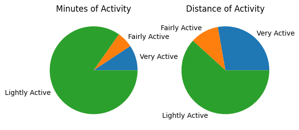

```python
fig, axs = plt.subplots(1,2)
axs[0].pie(minutes, labels = labels)
axs[0].set_title('Minutes of Activity')
axs[1].pie(dist, labels=labels)
axs[1].set_title('Distance of Activity')
```

**Discovery** Although our subjects spend the majority of their time in lightly active activities, the very active time accounts for a disproportionate amount of distance. This could suggest that the majority of users may be runners or cyclists. To further this, we could use minutes and distance to figure out athlete paces or speeds, but we'll leave that for now. I believe this is an important insight, the above pie charts will be remade in Tableau to give more customizability.

Given this insight, we can target marketing in one of two ways:

1. We can try to target athletes.
- People who use fitbit seem to be more likely to be interested in distance sports or longer cardio training. We can either add features, or emphasize existing features that will be wanted by distance runners in our marketing.
1. We could go the exact opposite route and target non-athletes
- There are a lot of activity trackers out there, and many of them (fitbit, garmin, whoop to name a few) already are targeting athletes. With Bellabeat's mission to create products for women, by women that are stylish, and also do menstrual tracking, I would recommend using this insight to actually go the opposite direction and target our marketing at "the every day woman" to aim to increase health metrics and know their body better even if they never intend to engage in high intensity exercise.

To be more thorough, we can look at average daily activity and distances by user. Let's come up with a way to come up with an average weekly "very active" distance.

```python
grouped = daily_cleaned.groupby('Id')
user_average_dist = []
for Id, group in grouped:
    tot_days = group.shape[0]
    if tot_days >= 7:
        num_weeks = tot_days//7
    else:
        num_weeks = 1
    avg_dist = np.sum(group.VeryActiveDistance)/num_weeks
    user_average_dist.append(avg_dist)

user_average_dist.sort()
```

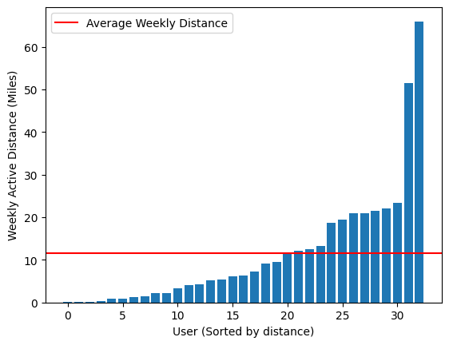

```python
fig, ax = plt.subplots()
ax.bar(x = np.arange(len(user_average_dist)),height = user_average_dist)
ax.set_xlabel('User (Sorted by distance)')
ax.set_ylabel('Weekly Active Distance (Miles)')
ax.axhline(np.mean(user_average_dist), color = 'r', label = 'Average Weekly Distance')
ax.legend()
#This chart can also be customized in tableau
```

A few things to note here that we can dive into if time allows: Our group is relatively active (average of over 10 miles per week of highly active distance), however there are two users which seem to be outliers in this case, just for fun, let's see if they are considered outliers by either IQR or standard deviation definitions

```
First Quartile: 2.1550000011920942, Third Quartile: 18.767499849200245, IQR 16.612499848008152
Bounds: (-22.763749770820134,43.68624962121247)
```

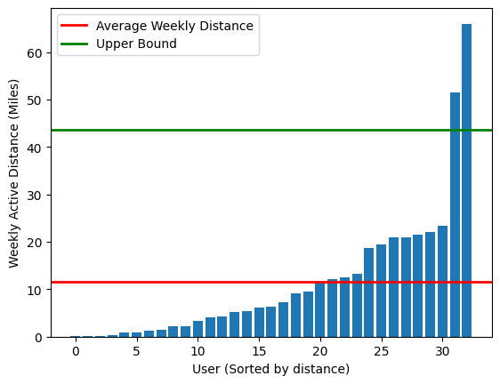

```python
q1,q3 = np.percentile(user_average_dist, [25,75])
iqr = q3-q1
print(f'First Quartile: {q1}, Third Quartile: {q3}, IQR {iqr}')

lower_bound = q1 - 1.5*iqr
upper_bound = q3 + 1.5*iqr

print(f'Bounds: ({lower_bound},{upper_bound})')

fig, ax = plt.subplots()
ax.bar(x = np.arange(len(user_average_dist)),height = user_average_dist)
ax.set_xlabel('User (Sorted by distance)')
ax.set_ylabel('Weekly Active Distance (Miles)')
ax.axhline(np.mean(user_average_dist), color = 'r', linewidth=2, label = 'Average Weekly Distance')
ax.axhline(upper_bound, color = 'g', linewidth=2, label='Upper Bound')
ax.legend()
#This chart can also be customized in tableau
```

This shows that our most active distance users are considered outliers by the IQR definition. This could be due to a different mode of activity (ie cycling), but these also may be highly active individuals, and it may be better to exclude them from our analysis.

```python
# Looking at how often subjects log activity manually
percent_logged = np.sum(daily_cleaned.TotalDistance)/np.sum(daily_cleaned.LoggedActivitiesDistance)
```

```python
print(f'Percent of tracked distance that was logged by user: {percent_logged:.2f}%')
```

[output not shown]

# Sleep Analysis

Let's look into any patterns that exist between activity and sleep for our potential users. To do this, we'll need to join our daily activity and daily sleep dataframes on both user and date.

```python
daily_sleep.head()
```

|  | Id | SleepDay | TotalSleepRecords | TotalMinutesAsleep | TotalTimeInBed |
| --- | --- | --- | --- | --- | --- |
| 0 | 1503960366 | 4/12/2016 12:00:00 AM | 1 | 327 | 346 |
| 1 | 1503960366 | 4/13/2016 12:00:00 AM | 2 | 384 | 407 |
| 2 | 1503960366 | 4/15/2016 12:00:00 AM | 1 | 412 | 442 |
| 3 | 1503960366 | 4/16/2016 12:00:00 AM | 2 | 340 | 367 |
| 4 | 1503960366 | 4/17/2016 12:00:00 AM | 1 | 700 | 712 |

First, notice that our "SleepDay" column includes both date and time, we only want the date in order to join correctly with our activity dataframe.

```python
daily_sleep['SleepDay'] = pd.to_datetime(daily_sleep['SleepDay'])
daily_sleep['Date'] = daily_sleep['SleepDay'].dt.date
daily_sleep.drop('SleepDay',axis=1, inplace=True)

daily_sleep.head()
```

|  | Id | TotalSleepRecords | TotalMinutesAsleep | TotalTimeInBed | Date |
| --- | --- | --- | --- | --- | --- |
| 0 | 1503960366 | 1 | 327 | 346 | 2016-04-12 |
| 1 | 1503960366 | 2 | 384 | 407 | 2016-04-13 |
| 2 | 1503960366 | 1 | 412 | 442 | 2016-04-15 |
| 3 | 1503960366 | 2 | 340 | 367 | 2016-04-16 |
| 4 | 1503960366 | 1 | 700 | 712 | 2016-04-17 |

```python
daily_activity['Date'] = pd.to_datetime(daily_activity['ActivityDate'])
daily_activity.drop(['ActivityDate'],axis=1, inplace=True)
daily_activity.head()
```

|  | Id | TotalSteps | TotalDistance | TrackerDistance | LoggedActivitiesDistance | VeryActiveDistance | ModeratelyActiveDistance | LightActiveDistance | SedentaryActiveDistance | VeryActiveMinutes | FairlyActiveMinutes | LightlyActiveMinutes | SedentaryMinutes | Calories | Date |
| --- | --- | --- | --- | --- | --- | --- | --- | --- | --- | --- | --- | --- | --- | --- | --- |
| 0 | 1503960366 | 13162 | 8.50 | 8.50 | 0.0 | 1.88 | 0.55 | 6.06 | 0.0 | 25 | 13 | 328 | 728 | 1985 | 2016-04-12 |
| 1 | 1503960366 | 10735 | 6.97 | 6.97 | 0.0 | 1.57 | 0.69 | 4.71 | 0.0 | 21 | 19 | 217 | 776 | 1797 | 2016-04-13 |
| 2 | 1503960366 | 10460 | 6.74 | 6.74 | 0.0 | 2.44 | 0.40 | 3.91 | 0.0 | 30 | 11 | 181 | 1218 | 1776 | 2016-04-14 |
| 3 | 1503960366 | 9762 | 6.28 | 6.28 | 0.0 | 2.14 | 1.26 | 2.83 | 0.0 | 29 | 34 | 209 | 726 | 1745 | 2016-04-15 |
| 4 | 1503960366 | 12669 | 8.16 | 8.16 | 0.0 | 2.71 | 0.41 | 5.04 | 0.0 | 36 | 10 | 221 | 773 | 1863 | 2016-04-16 |

Now the datatypes and formatting of our Date and ID columns match, so we can perform a join between these tables. We want to use an Inner join on ID and Date so that we're only looking at entries for which we have both activity and sleep data.

```python
daily_sleep['Date'] = daily_sleep['Date'].astype(str)
daily_activity['Date'] = daily_activity['Date'].astype(str)

total_daily = daily_activity.merge(daily_sleep, how='inner', on =['Id','Date'])
total_daily.head()
```

|  | Id | TotalSteps | TotalDistance | TrackerDistance | LoggedActivitiesDistance | VeryActiveDistance | ModeratelyActiveDistance | LightActiveDistance | SedentaryActiveDistance | VeryActiveMinutes | FairlyActiveMinutes | LightlyActiveMinutes | SedentaryMinutes | Calories | Date | TotalSleepRecords | TotalMinutesAsleep | TotalTimeInBed |
| --- | --- | --- | --- | --- | --- | --- | --- | --- | --- | --- | --- | --- | --- | --- | --- | --- | --- | --- |
| 0 | 1503960366 | 13162 | 8.50 | 8.50 | 0.0 | 1.88 | 0.55 | 6.06 | 0.0 | 25 | 13 | 328 | 728 | 1985 | 2016-04-12 | 1 | 327 | 346 |
| 1 | 1503960366 | 10735 | 6.97 | 6.97 | 0.0 | 1.57 | 0.69 | 4.71 | 0.0 | 21 | 19 | 217 | 776 | 1797 | 2016-04-13 | 2 | 384 | 407 |
| 2 | 1503960366 | 9762 | 6.28 | 6.28 | 0.0 | 2.14 | 1.26 | 2.83 | 0.0 | 29 | 34 | 209 | 726 | 1745 | 2016-04-15 | 1 | 412 | 442 |
| 3 | 1503960366 | 12669 | 8.16 | 8.16 | 0.0 | 2.71 | 0.41 | 5.04 | 0.0 | 36 | 10 | 221 | 773 | 1863 | 2016-04-16 | 2 | 340 | 367 |
| 4 | 1503960366 | 9705 | 6.48 | 6.48 | 0.0 | 3.19 | 0.78 | 2.51 | 0.0 | 38 | 20 | 164 | 539 | 1728 | 2016-04-17 | 1 | 700 | 712 |

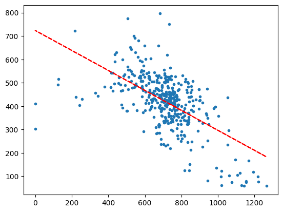

```python
x = total_daily.SedentaryMinutes
y = total_daily.TotalMinutesAsleep
z = np.polyfit(x,y,1)
y_hat = np.poly1d(z)(x)

fig, ax = plt.subplots()
ax.plot(x, y, '.')
ax.plot(x,y_hat,'r--')
```

```python
from scipy.stats import pearsonr
r,p = pearsonr(x,y)
print(f'Pearson Correlation Coefficient: {r}')
```

```
Pearson Correlation Coefficient: -0.59939400560339
```

**Discovery** With a correlation coefficient of -0.6, there is a resonably strong negative correlation between sedentary minutes and minutes asleep. We can market this as a method of increased time and quality of sleep. If bellabeat customers want to increase their time asleep, they can do so by decreasing their sedentary minutes. We may be able to implement alerts or daily challenges in the app to encourage our clients to moderately increase their non-sedentary minutes during the work day.

```python
from sklearn.linear_model import LinearRegression
from sklearn.feature_selection import SequentialFeatureSelector

X = total_daily.drop(['Id', 'Date','TotalSleepRecords','TotalMinutesAsleep'],axis=1)
y = total_daily['TotalMinutesAsleep']

lin = LinearRegression()

sfs = SequentialFeatureSelector(lin,n_features_to_select= 5, direction='backward')
sfs.fit(X,y)
x_cols = np.array(sfs.get_feature_names_out())

for i,name in enumerate(x_cols):
    if i ==0:
        print('Top predictors\n----------------------------')
    print(f'{i+1}: {name}')
```

```
Top predictors
----------------------------
1: VeryActiveDistance
2: VeryActiveMinutes
3: SedentaryMinutes
4: Calories
5: TotalTimeInBed
```

```python
from sklearn.model_selection import train_test_split
from sklearn.metrics import r2_score, mean_squared_error

X_train, X_test, y_train, y_test = train_test_split(X,y, test_size=0.2)

lin.fit(X_train,y_train)
y_pred=lin.predict(X_test)

r2 = r2_score(y_test,y_pred)
mse = mean_squared_error(y_test,y_pred)

print(f'R2: {r2}, MSE: {mse}')
```

```
R2: 0.7652944078894455, MSE: 3702.498329536031
```

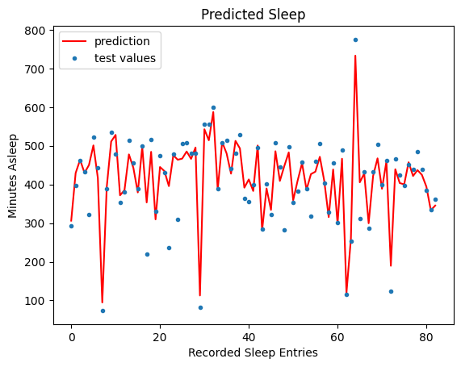

```python
t = np.arange(len(y_test))
plt.plot(t,y_pred, 'r', label = 'prediction')
plt.plot(t,y_test, '.', label = 'test values')
plt.title('Predicted Sleep')
plt.xlabel('Recorded Sleep Entries')
plt.ylabel('Minutes Asleep')
plt.legend()
```

```python
for name, weight in zip(X.columns, lin.coef_):
    print(f'{name}: {weight}')
```

```
TotalSteps: 0.02202708992639055
TotalDistance: -24.660865867746196
TrackerDistance: -70.24950832122347
LoggedActivitiesDistance: -10.939322208907614
VeryActiveDistance: 67.36780988034631
ModeratelyActiveDistance: 69.25985508331101
LightActiveDistance: 58.209331437023515
SedentaryActiveDistance: 175.81933488535313
VeryActiveMinutes: -0.5526289245759881
FairlyActiveMinutes: -1.1334697606446125
LightlyActiveMinutes: 0.0019459249313364957
SedentaryMinutes: -0.08610384542758065
Calories: 0.05776606959240027
TotalTimeInBed: 0.8142731549427189
```

```python
X_sparse = X.loc[:,x_cols]


X_train, X_test, y_train, y_test = train_test_split(X_sparse,y, test_size=0.2)

lin.fit(X_train,y_train)
y_pred=lin.predict(X_test)

r2 = r2_score(y_test,y_pred)
mse = mean_squared_error(y_test,y_pred)

print(f'R2: {r2}, MSE: {mse}')
```

```
R2: 0.8381670191824347, MSE: 2078.26745565209
```

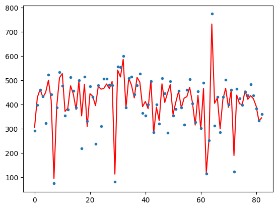

```python
t = np.arange(len(y_test))
plt.plot(t,y_pred, 'r')
plt.plot(t,y_test, '.')
```

```python
for name, weight in zip(X_sparse.columns, lin.coef_):
    print(f'{name}: {weight}')
```

```
VeryActiveDistance: 1.5977641919826824
VeryActiveMinutes: -0.31327015982353223
SedentaryMinutes: -0.046550689450416835
Calories: 0.021945889821249065
TotalTimeInBed: 0.826732342068614
```